# Panel Data Regression Using Jamovi

## Step 2: Panel Data Regression

In panel data regression, it’s essential to control for specific unobserved effects that are specific to each bank and remain fairly constant over time. Examples might be the types of customers each bank attracts, as some may attract younger customers and some older customers. Another example might be the types of financial products the bank trades in. These might differ between banks but stay relatively constant over time but may explain some of the differences in Tobin’s Q.

Whilst Jamovi can’t handle advanced panel regression models very easily, we can use it to implement a fixed effects regression technique for panel regression. Whilst this is somewhat limited for panel data regression, this approach offers a practical and scientifically sound method for panel data analysis.

From the Jamovi **Regression** menu, click on **Linear Regression**:

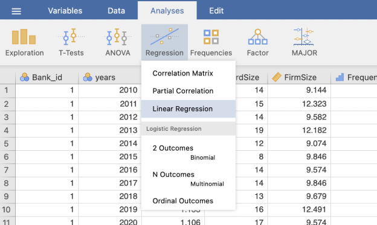

Then, move our dependent variable, “TobinQ”, to the **Dependent variable** box:

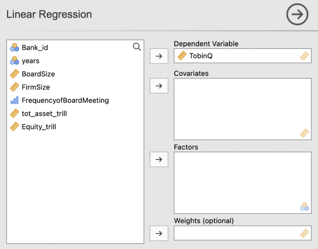

Next, we need to select two key variables: “Bank_id” which identifies each bank, and “years” which specifies the time frame. These two types of variables are essential in panel data regression; one tells us about the individual entity (in this case, banks) and the other about the time period linking the same data to each bank together. These are both categorical (Nominal) variables and so place these two variables in the “Factors” box as shown below. If you have any other categorical predictors then these need to be in the Factors box as well (in our case we don’t).

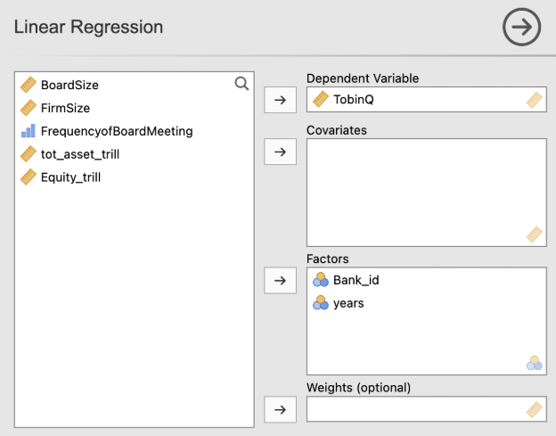

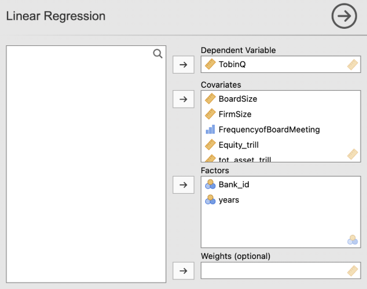